# R For Data Science - Homework 1

Francisco Grisanti - PSID 1565858 - Date 2/21/2019

# Weekly Dataset

## The dataset is organized this way (see subset) and multiple observations are gathered across weeks of years 1990-2010

A subset of Weekly dataset

| Year | Lag1 | Lag2 | Lag3 | Lag4 | Lag5 | Volume | Today | Direction |
| --- | --- | --- | --- | --- | --- | --- | --- | --- |
| 1990 | 0.816 | 1.572 | -3.936 | -0.229 | -3.484 | 0.1549760 | -0.270 | Down |
| 1990 | -0.270 | 0.816 | 1.572 | -3.936 | -0.229 | 0.1485740 | -2.576 | Down |
| 1990 | -2.576 | -0.270 | 0.816 | 1.572 | -3.936 | 0.1598375 | 3.514 | Up |
| 1990 | 3.514 | -2.576 | -0.270 | 0.816 | 1.572 | 0.1616300 | 0.712 | Up |
| 1990 | 0.712 | 3.514 | -2.576 | -0.270 | 0.816 | 0.1537280 | 1.178 | Up |

## The summary of all variables and observations

Summary statistics of all features(min, max, mean, median, 1st Q, 3rd Q)

|  | Year | Lag1 | Lag2 | Lag3 | Lag4 | Lag5 | Volume | Today | Direction |
| --- | --- | --- | --- | --- | --- | --- | --- | --- | --- |
|  | Min. :1990 | Min. :-18.1950 | Min. :-18.1950 | Min. :-18.1950 | Min. :-18.1950 | Min. :-18.1950 | Min. :0.08747 | Min. :-18.1950 | Down:484 |
|  | 1st Qu.:1995 | 1st Qu.: -1.1540 | 1st Qu.: -1.1540 | 1st Qu.: -1.1580 | 1st Qu.: -1.1580 | 1st Qu.: -1.1660 | 1st Qu.:0.33202 | 1st Qu.: -1.1540 | Up :605 |
|  | Median :2000 | Median : 0.2410 | Median : 0.2410 | Median : 0.2410 | Median : 0.2380 | Median : 0.2340 | Median :1.00268 | Median : 0.2410 | NA |
|  | Mean :2000 | Mean : 0.1506 | Mean : 0.1511 | Mean : 0.1472 | Mean : 0.1458 | Mean : 0.1399 | Mean :1.57462 | Mean : 0.1499 | NA |
|  | 3rd Qu.:2005 | 3rd Qu.: 1.4050 | 3rd Qu.: 1.4090 | 3rd Qu.: 1.4090 | 3rd Qu.: 1.4090 | 3rd Qu.: 1.4050 | 3rd Qu.:2.05373 | 3rd Qu.: 1.4050 | NA |
|  | Max. :2010 | Max. : 12.0260 | Max. : 12.0260 | Max. : 12.0260 | Max. : 12.0260 | Max. : 12.0260 | Max. :9.32821 | Max. : 12.0260 | NA |

Total count of days the market was up or down

|  | x |
| --- | --- |
| Down | 484 |
| Up | 605 |

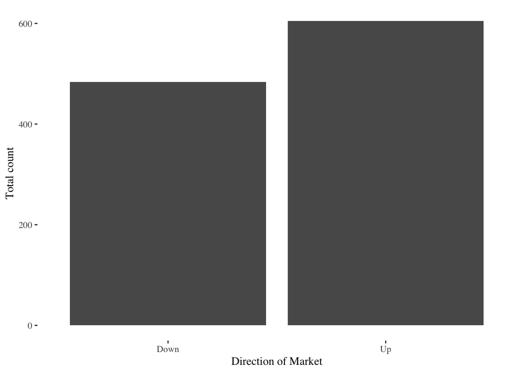